# Ford gobike Data Analysis

## by Babatunde Olaniyi

## Investigation Overview

> I'm most interested in investigating bike trip duration and bike trip start time as dependent variables and its relationship with other variables in the dataset. I am also interested in investigating to see if there are certain bikes which are most commonly used by the users.

## Dataset Overview

> The data consists of information regarding approximately 183,000 rides made in a bike-sharing system covering the greater San Francisco Bay area. The data features include duration (secs) and others such as DateTime, customer type, and gender, as well as additional variables such as member's year of birth, start and end station name, start and end station longitude and latitude, start and end station unique id among others. About 8000 data points were removed from the analysis due to inconsistencies or missing information.

## The most popular bikes

> A plot of the *TOP TEN* bikes shows the most popular bikes among the bikes used for the bike sharing business. Bike with ID *4794* is the most popular.

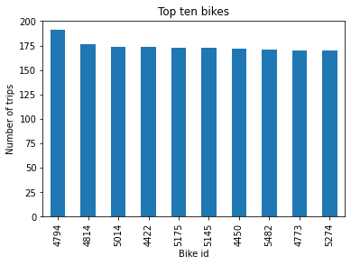

## Distribution of Bike trip start hours

> The time stamp in the start_time column was split to remove the date and create another column for Hours. Then a distribution of these hours was created to visualize the hours of the day with most bike rides with the peak ocurring between 17:00hrs and 18:00hrs.

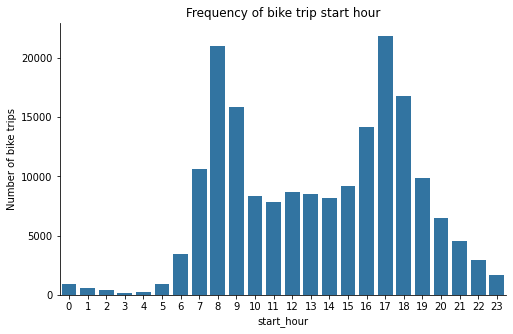

## Relationship between member age, gender and bike trip duration

> The visuals shows that most users will likely do shorter duration trips below *10000 seconds*.

> Younger users of ages 20 to 40 years are more likely to do long duration of bike trips.

> The plot also shows more saturation for the males and this implies that most users are males.

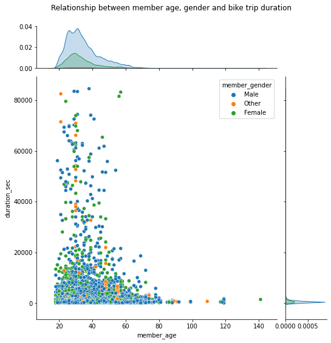

## Relationship between trip duration, user type, gender and days of the week

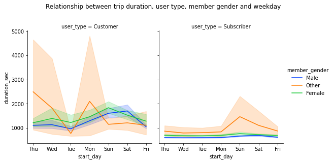